# 10-Date-and-Time-Date-Pandas-Demo

### This notebook contains some code and comments from:

Python Pandas Tutorial (Part 10): Cleaning Data - Working with Dates and Time Series Data  
https://www.youtube.com/watch?v=UFuo7EHI8zc

```python
import pandas as pd
import datetime
```

**Dataset**  
Erethium crypto currency data broken down by hour for a few years.

```python
df = pd.read_csv('C:/Users/repaschall/Documents/py_projects/learn_python_2_top/cs_pandas_data_ETH/ETH_1h.csv')
```

```python
df.head()
```

|  | Date | Symbol | Open | High | Low | Close | Volume |
| --- | --- | --- | --- | --- | --- | --- | --- |
| 0 | 2020-03-13 08-PM | ETHUSD | 129.94 | 131.82 | 126.87 | 128.71 | 1940673.93 |
| 1 | 2020-03-13 07-PM | ETHUSD | 119.51 | 132.02 | 117.10 | 129.94 | 7579741.09 |
| 2 | 2020-03-13 06-PM | ETHUSD | 124.47 | 124.85 | 115.50 | 119.51 | 4898735.81 |
| 3 | 2020-03-13 05-PM | ETHUSD | 124.08 | 127.42 | 121.63 | 124.47 | 2753450.92 |
| 4 | 2020-03-13 04-PM | ETHUSD | 124.85 | 129.51 | 120.17 | 124.08 | 4461424.71 |

**23674 rows, 7 columns**  
See the df shape attribute

```python
df.shape
```

```
(23674, 7)
```

**Date column not datetime object**  
A date in Python is not a data type of its own.  
We can import a module named datetime to work with dates as date objects.  
Beware: the values in the Date column are String (str) objects, not datetime objects.  
See the df dtypes attribute to learn the data types for each column in df.  
Strings are objects in Python which means that there is a set of built-in functions that you can use to manipulate strings.  
You use dot-notation to invoke the functions on a string object such as sentence.

```python
df.dtypes
```

```
Date       object
Symbol     object
Open      float64
High      float64
Low       float64
Close     float64
Volume    float64
dtype: object
```

**Isolate one cell in Date column**  
Examine the data type for a single cell in the Date column.  
See the data type indicates that it is a String (str) object.

```python
type(df.loc[0,'Date'])
```

```
str
```

**Running the pandas datetime method won't work**  
The dayname method returns the name of the day of the week for that date.  
This line of code will fail because the day_name method is not being called on datetime object.  
See above that df.loc[0,'Date']) is a String object (not a datetime object).  
Error message states: AttributeError: 'str' object has no attribute 'day_name'

```python
#df.loc[0,'Date'].day_name()
```

**Time: 3:41**

**Convert attempt #1**  
Need to convert (a.k.a. cast) the Date column to contain datetime objects.  
One approach would be to use the pandas to_datetime function.  
However, the code below is commented out because it will not work.  
The reason the code won't work is because values in the Date column are not in a standard format.  
This non-standard format means the to_datetime function might result in an error or possible might run, but would not produce the desired conversion.  
Bottom line, for our data here, we must use a conversion approach that specifies how the date is formatted in the df Date column.

```python
#df['Date'] = pd.to_datetime(df['Date'])
```

**Convert attempt #2**  
A better approach considering the non-standard format of the df Date column is described below.  
Pass a format mask as the second argument to the to_datetime function.  
URL for Datetime Formatting Codes: http://bit.ly/python-dt-fmt  
URL for Pandas Date Offset Codes: http://bit.ly/pandas-dt-fmt

```python
df['Date'] = pd.to_datetime(df['Date'], format='%Y-%m-%d %I-%p')
df['Date']
```

```
0       2020-03-13 20:00:00
1       2020-03-13 19:00:00
2       2020-03-13 18:00:00
3       2020-03-13 17:00:00
4       2020-03-13 16:00:00
                ...
23669   2017-07-01 15:00:00
23670   2017-07-01 14:00:00
23671   2017-07-01 13:00:00
23672   2017-07-01 12:00:00
23673   2017-07-01 11:00:00
Name: Date, Length: 23674, dtype: datetime64[ns]
```

```python
type(df.loc[0, 'Date'])
```

```
pandas._libs.tslibs.timestamps.Timestamp
```

```python
df.loc[0, 'Date'].day_name()
```

```
'Friday'
```

**Time: 7:47**

**Convert to datetime when reading file**  
It's possible to convert the Date column to be a datetime object as the data is read and loaded into a DataFrame.  
This approach requires adding one and possibley two new arguments when calling the pandas read_csv function.  
The first new argument is parse_dates where the value is a list containing the name(s) of the columns to be converted.  
For our data, it's necessary to also pass a date_parser argument on the call to read_csv. See below for more details.

**Add arguments to read_csv**  
The code below uses a lambda to apply the pandas datetime object's strptime method to each element in the df Date column.  
The lambda function converts each String to a datetime object.  
The x in the lambda function represents each individual String, i.e. each individual date.  
To clarify, each individual date in the .csv file is sent through the lambda function.  
The strptime method converts a String object to a datetime object.  
Repeating for emphasis: each String in the Date column of the .csv file will be converted to a datetime object as it's read into df.  
Recall for our data, the date in the .csv file is not in a standard format that Python can recognize.  
If the date was in a Python standard format then it would not be necessary to pass the date_parser argument on the call to read_csv.  
Since our date data (in the .csv file) is not in standard format then it's necessary to create the lambda function as described below.  
The date_parser argument is assigned a value that is the name of the function that converts the String to a datetime object.  
The function passed to the date_parser argument uses the same String date format mask as was used earlier when using the pd.to_datetime function.  
See how the strptime method takes a second argument that is a format mask that specifically aligns with the date format in the String in the .csv file.  
URL for Datetime Formatting Codes: http://bit.ly/python-dt-fmt  
URL for Pandas Date Offset Codes: http://bit.ly/pandas-dt-fmt  
Executing this lambda function will accurately convert each element in the Date column from a String object to a datetime object.  
The first line of code assigns the lambda to a variable named d_parser, i.e. d_parser points to (i.e. references) the lambda function. Doing so effectively converts the anonymous lambda function into a named function since you can now reference it with the d_parser variable.  
Be aware, you can create a traditional named function instead of using a lambda function.  
https://stackoverflow.com/questions/37042922/datetime-strptime-in-python-pandas-whats-wrong

```python
#d_parser = lambda x: pd.datetime.strptime(x, '%Y-%m-%d %I-%p')
d_parser = lambda x: datetime.datetime.strptime(x, '%Y-%m-%d %I-%p')
df = pd.read_csv('C:/Users/repaschall/Documents/py_projects/learn_python_2_top/cs_pandas_data_ETH/ETH_1h.csv', parse_dates=['Date'], date_parser=d_parser)
```

**Time: 10:30**

**Date loaded in as datetime**  
The output from head indicates the data in the Date column is a datetime object.

```python
df.head()
```

|  | Date | Symbol | Open | High | Low | Close | Volume |
| --- | --- | --- | --- | --- | --- | --- | --- |
| 0 | 2020-03-13 20:00:00 | ETHUSD | 129.94 | 131.82 | 126.87 | 128.71 | 1940673.93 |
| 1 | 2020-03-13 19:00:00 | ETHUSD | 119.51 | 132.02 | 117.10 | 129.94 | 7579741.09 |
| 2 | 2020-03-13 18:00:00 | ETHUSD | 124.47 | 124.85 | 115.50 | 119.51 | 4898735.81 |
| 3 | 2020-03-13 17:00:00 | ETHUSD | 124.08 | 127.42 | 121.63 | 124.47 | 2753450.92 |
| 4 | 2020-03-13 16:00:00 | ETHUSD | 124.85 | 129.51 | 120.17 | 124.08 | 4461424.71 |

**Date column**  
The Date column in the df Dataframe is a Series object.

```python
type(df['Date'])
```

```
pandas.core.series.Series
```

**TimeStamp**  
The first element in the Date Series is Timestamp, which probably means it's a datetime object.

```python
type(df.loc[0, 'Date'])
```

```
pandas._libs.tslibs.timestamps.Timestamp
```

**day_name is a datetime method**  
Call the day_name method on a datetime object.

```python
df.loc[0, 'Date'].day_name()
```

```
'Friday'
```

**Time 12:17**

**Run datetime method on Series**  
Run the day_name method on the entire Date Series.  
Access the dt class on the Series object and access the datetime methods that way.  
Using the dt class on a Series is similar to accessing the string (or str) class to use the string methods on an entire Series object.  
Access the dt class on a Series object with this code: df['Date'].dt  
Now call the day_name method by adding .day_name()  
https://pandas.pydata.org/pandas-docs/stable/user_guide/basics.html#dt-accessor  
The code below returns the day of the week for each element in the Date Series of the df DataFrame.

```python
df['Date'].dt.day_name()
```

```
0          Friday
1          Friday
2          Friday
3          Friday
4          Friday
           ...
23669    Saturday
23670    Saturday
23671    Saturday
23672    Saturday
23673    Saturday
Name: Date, Length: 23674, dtype: object
```

**Create a new df column**  
Create a new column named DayOfWeek on df so we can easily see the day of the week when each trade occurred.  
The code df['DayOfWeek'] = creates a new column on the df object.  
Assign the Series created by this code: df['Date'].dt.day_name()

```python
df['DayOfWeek'] = df['Date'].dt.day_name()
```

```python
df
```

|  | Date | Symbol | Open | High | Low | Close | Volume | DayOfWeek |
| --- | --- | --- | --- | --- | --- | --- | --- | --- |
| 0 | 2020-03-13 20:00:00 | ETHUSD | 129.94 | 131.82 | 126.87 | 128.71 | 1940673.93 | Friday |
| 1 | 2020-03-13 19:00:00 | ETHUSD | 119.51 | 132.02 | 117.10 | 129.94 | 7579741.09 | Friday |
| 2 | 2020-03-13 18:00:00 | ETHUSD | 124.47 | 124.85 | 115.50 | 119.51 | 4898735.81 | Friday |
| 3 | 2020-03-13 17:00:00 | ETHUSD | 124.08 | 127.42 | 121.63 | 124.47 | 2753450.92 | Friday |
| 4 | 2020-03-13 16:00:00 | ETHUSD | 124.85 | 129.51 | 120.17 | 124.08 | 4461424.71 | Friday |
| ... | ... | ... | ... | ... | ... | ... | ... | ... |
| 23669 | 2017-07-01 15:00:00 | ETHUSD | 265.74 | 272.74 | 265.00 | 272.57 | 1500282.55 | Saturday |
| 23670 | 2017-07-01 14:00:00 | ETHUSD | 268.79 | 269.90 | 265.00 | 265.74 | 1702536.85 | Saturday |
| 23671 | 2017-07-01 13:00:00 | ETHUSD | 274.83 | 274.93 | 265.00 | 268.79 | 3010787.99 | Saturday |
| 23672 | 2017-07-01 12:00:00 | ETHUSD | 275.01 | 275.01 | 271.00 | 274.83 | 824362.87 | Saturday |
| 23673 | 2017-07-01 11:00:00 | ETHUSD | 279.98 | 279.99 | 272.10 | 275.01 | 679358.87 | Saturday |

23674 rows × 8 columns

**Time: 13:09**

**Explore data in df**  
Explore data, especially the Date column in df.

Find the earliest and latest (most recent) dates.

```python
df['Date'].min()
```

```
Timestamp('2017-07-01 11:00:00')
```

```python
df['Date'].max()
```

```
Timestamp('2020-03-13 20:00:00')
```

Find the difference between dates, the amount of time between two dates.  
What is returned is a Timedelta object.

```python
df['Date'].max() - df['Date'].min()
```

```
Timedelta('986 days 09:00:00')
```

```python
type(df['Date'].max() - df['Date'].min())
```

```
pandas._libs.tslibs.timedeltas.Timedelta
```

**Filter by date**

Create a named filter (i.e. the filt variable)  
Access the rows just for the year 2020.

The code below uses the string '2020'.  
Python will recognize '2020' as a standard format for year.  
Put the filter in square brackets, i.e. using logical indexing on the .loc indexer.  
What's returned are the df rows where the year in the Data column is 2020.

```python
filt = (df['Date'] >= '2020')
df.loc[filt]
```

|  | Date | Symbol | Open | High | Low | Close | Volume | DayOfWeek |
| --- | --- | --- | --- | --- | --- | --- | --- | --- |
| 0 | 2020-03-13 20:00:00 | ETHUSD | 129.94 | 131.82 | 126.87 | 128.71 | 1940673.93 | Friday |
| 1 | 2020-03-13 19:00:00 | ETHUSD | 119.51 | 132.02 | 117.10 | 129.94 | 7579741.09 | Friday |
| 2 | 2020-03-13 18:00:00 | ETHUSD | 124.47 | 124.85 | 115.50 | 119.51 | 4898735.81 | Friday |
| 3 | 2020-03-13 17:00:00 | ETHUSD | 124.08 | 127.42 | 121.63 | 124.47 | 2753450.92 | Friday |
| 4 | 2020-03-13 16:00:00 | ETHUSD | 124.85 | 129.51 | 120.17 | 124.08 | 4461424.71 | Friday |
| ... | ... | ... | ... | ... | ... | ... | ... | ... |
| 1744 | 2020-01-01 04:00:00 | ETHUSD | 129.57 | 130.00 | 129.50 | 129.56 | 702786.82 | Wednesday |
| 1745 | 2020-01-01 03:00:00 | ETHUSD | 130.37 | 130.44 | 129.38 | 129.57 | 496704.23 | Wednesday |
| 1746 | 2020-01-01 02:00:00 | ETHUSD | 130.14 | 130.50 | 129.91 | 130.37 | 396315.72 | Wednesday |
| 1747 | 2020-01-01 01:00:00 | ETHUSD | 128.34 | 130.14 | 128.32 | 130.14 | 635419.40 | Wednesday |
| 1748 | 2020-01-01 00:00:00 | ETHUSD | 128.54 | 128.54 | 128.12 | 128.34 | 245119.91 | Wednesday |

1749 rows × 8 columns

**Using strings in logical expressions**  
Find all df rows for every transaction that occurred in 2019.  
Construct a filter that has both lower and upper bounds.  
Strings are used to represent years in the logical expressions.  
Python will figure out that (for example) the string '2019' is the year 2019.

```python
 filt = (df['Date'] >= '2019') & (df['Date'] < '2020')
df.loc[filt]
```

|  | Date | Symbol | Open | High | Low | Close | Volume | DayOfWeek |
| --- | --- | --- | --- | --- | --- | --- | --- | --- |
| 1749 | 2019-12-31 23:00:00 | ETHUSD | 128.33 | 128.69 | 128.14 | 128.54 | 440678.91 | Tuesday |
| 1750 | 2019-12-31 22:00:00 | ETHUSD | 128.38 | 128.69 | 127.95 | 128.33 | 554646.02 | Tuesday |
| 1751 | 2019-12-31 21:00:00 | ETHUSD | 127.86 | 128.43 | 127.72 | 128.38 | 350155.69 | Tuesday |
| 1752 | 2019-12-31 20:00:00 | ETHUSD | 127.84 | 128.34 | 127.71 | 127.86 | 428183.38 | Tuesday |
| 1753 | 2019-12-31 19:00:00 | ETHUSD | 128.69 | 128.69 | 127.60 | 127.84 | 1169847.84 | Tuesday |
| ... | ... | ... | ... | ... | ... | ... | ... | ... |
| 10504 | 2019-01-01 04:00:00 | ETHUSD | 130.75 | 133.96 | 130.74 | 131.96 | 2791135.37 | Tuesday |
| 10505 | 2019-01-01 03:00:00 | ETHUSD | 130.06 | 130.79 | 130.06 | 130.75 | 503732.63 | Tuesday |
| 10506 | 2019-01-01 02:00:00 | ETHUSD | 130.79 | 130.88 | 129.55 | 130.06 | 838183.43 | Tuesday |
| 10507 | 2019-01-01 01:00:00 | ETHUSD | 131.62 | 131.62 | 130.77 | 130.79 | 434917.99 | Tuesday |
| 10508 | 2019-01-01 00:00:00 | ETHUSD | 130.53 | 131.91 | 130.48 | 131.62 | 1067136.21 | Tuesday |

8760 rows × 8 columns

**Using datetime objects in logical expressions**  
Use the pandas to_datetime function to convert standard formatted strings to datetime objects.  
These datetime objects are then used in the logical expressions.  
The code below produces the same results as the code above.

```python
filt = (df['Date'] >= pd.to_datetime('2019-01-01')) & (df['Date'] < pd.to_datetime('2020-01-01'))
df.loc[filt]
```

|  | Date | Symbol | Open | High | Low | Close | Volume | DayOfWeek |
| --- | --- | --- | --- | --- | --- | --- | --- | --- |
| 1749 | 2019-12-31 23:00:00 | ETHUSD | 128.33 | 128.69 | 128.14 | 128.54 | 440678.91 | Tuesday |
| 1750 | 2019-12-31 22:00:00 | ETHUSD | 128.38 | 128.69 | 127.95 | 128.33 | 554646.02 | Tuesday |
| 1751 | 2019-12-31 21:00:00 | ETHUSD | 127.86 | 128.43 | 127.72 | 128.38 | 350155.69 | Tuesday |
| 1752 | 2019-12-31 20:00:00 | ETHUSD | 127.84 | 128.34 | 127.71 | 127.86 | 428183.38 | Tuesday |
| 1753 | 2019-12-31 19:00:00 | ETHUSD | 128.69 | 128.69 | 127.60 | 127.84 | 1169847.84 | Tuesday |
| ... | ... | ... | ... | ... | ... | ... | ... | ... |
| 10504 | 2019-01-01 04:00:00 | ETHUSD | 130.75 | 133.96 | 130.74 | 131.96 | 2791135.37 | Tuesday |
| 10505 | 2019-01-01 03:00:00 | ETHUSD | 130.06 | 130.79 | 130.06 | 130.75 | 503732.63 | Tuesday |
| 10506 | 2019-01-01 02:00:00 | ETHUSD | 130.79 | 130.88 | 129.55 | 130.06 | 838183.43 | Tuesday |
| 10507 | 2019-01-01 01:00:00 | ETHUSD | 131.62 | 131.62 | 130.77 | 130.79 | 434917.99 | Tuesday |
| 10508 | 2019-01-01 00:00:00 | ETHUSD | 130.53 | 131.91 | 130.48 | 131.62 | 1067136.21 | Tuesday |

8760 rows × 8 columns

**Time: 18:30**

**Set index to Date**  
All timestamps, i.e. values in the Date column are unique.  
So, it would be a good idea to set the index to be the Date column.

```python
df.set_index('Date', inplace=True)
```

```python
df
```

| Date | Symbol | Open | High | Low | Close | Volume | DayOfWeek |
| --- | --- | --- | --- | --- | --- | --- | --- |
| 2020-03-13 20:00:00 | ETHUSD | 129.94 | 131.82 | 126.87 | 128.71 | 1940673.93 | Friday |
| 2020-03-13 19:00:00 | ETHUSD | 119.51 | 132.02 | 117.10 | 129.94 | 7579741.09 | Friday |
| 2020-03-13 18:00:00 | ETHUSD | 124.47 | 124.85 | 115.50 | 119.51 | 4898735.81 | Friday |
| 2020-03-13 17:00:00 | ETHUSD | 124.08 | 127.42 | 121.63 | 124.47 | 2753450.92 | Friday |
| 2020-03-13 16:00:00 | ETHUSD | 124.85 | 129.51 | 120.17 | 124.08 | 4461424.71 | Friday |
| ... | ... | ... | ... | ... | ... | ... | ... |
| 2017-07-01 15:00:00 | ETHUSD | 265.74 | 272.74 | 265.00 | 272.57 | 1500282.55 | Saturday |
| 2017-07-01 14:00:00 | ETHUSD | 268.79 | 269.90 | 265.00 | 265.74 | 1702536.85 | Saturday |
| 2017-07-01 13:00:00 | ETHUSD | 274.83 | 274.93 | 265.00 | 268.79 | 3010787.99 | Saturday |
| 2017-07-01 12:00:00 | ETHUSD | 275.01 | 275.01 | 271.00 | 274.83 | 824362.87 | Saturday |
| 2017-07-01 11:00:00 | ETHUSD | 279.98 | 279.99 | 272.10 | 275.01 | 679358.87 | Saturday |

23674 rows × 7 columns

**Get just 2019 rows**  
**NOTE: Video error**  
The vido uses this code: df['2019'] but it fails.  
So I used df.loc['2019'] Since Date is the index, you filter the date just by passing them into the brackets.  
Repeating for emphasis, you can use the bracket notation to select just the rows where Date is the year 2019. *

```python
df.loc['2019']
```

| Date | Symbol | Open | High | Low | Close | Volume | DayOfWeek |
| --- | --- | --- | --- | --- | --- | --- | --- |
| 2019-12-31 23:00:00 | ETHUSD | 128.33 | 128.69 | 128.14 | 128.54 | 440678.91 | Tuesday |
| 2019-12-31 22:00:00 | ETHUSD | 128.38 | 128.69 | 127.95 | 128.33 | 554646.02 | Tuesday |
| 2019-12-31 21:00:00 | ETHUSD | 127.86 | 128.43 | 127.72 | 128.38 | 350155.69 | Tuesday |
| 2019-12-31 20:00:00 | ETHUSD | 127.84 | 128.34 | 127.71 | 127.86 | 428183.38 | Tuesday |
| 2019-12-31 19:00:00 | ETHUSD | 128.69 | 128.69 | 127.60 | 127.84 | 1169847.84 | Tuesday |
| ... | ... | ... | ... | ... | ... | ... | ... |
| 2019-01-01 04:00:00 | ETHUSD | 130.75 | 133.96 | 130.74 | 131.96 | 2791135.37 | Tuesday |
| 2019-01-01 03:00:00 | ETHUSD | 130.06 | 130.79 | 130.06 | 130.75 | 503732.63 | Tuesday |
| 2019-01-01 02:00:00 | ETHUSD | 130.79 | 130.88 | 129.55 | 130.06 | 838183.43 | Tuesday |
| 2019-01-01 01:00:00 | ETHUSD | 131.62 | 131.62 | 130.77 | 130.79 | 434917.99 | Tuesday |
| 2019-01-01 00:00:00 | ETHUSD | 130.53 | 131.91 | 130.48 | 131.62 | 1067136.21 | Tuesday |

8760 rows × 7 columns

**Use slicing**  
To get dates for a specific range, then use slice.  
Get all of the rows for Jan and Feb of 2020.

```python
df['2020-01':'2020-02']
```

| Date | Symbol | Open | High | Low | Close | Volume | DayOfWeek |
| --- | --- | --- | --- | --- | --- | --- | --- |
| 2020-02-29 23:00:00 | ETHUSD | 223.35 | 223.58 | 216.83 | 217.31 | 1927939.88 | Saturday |
| 2020-02-29 22:00:00 | ETHUSD | 223.48 | 223.59 | 222.14 | 223.35 | 535998.57 | Saturday |
| 2020-02-29 21:00:00 | ETHUSD | 224.63 | 225.14 | 222.74 | 223.48 | 561158.03 | Saturday |
| 2020-02-29 20:00:00 | ETHUSD | 225.31 | 225.33 | 223.50 | 224.63 | 511648.65 | Saturday |
| 2020-02-29 19:00:00 | ETHUSD | 225.09 | 225.85 | 223.87 | 225.31 | 1250856.20 | Saturday |
| ... | ... | ... | ... | ... | ... | ... | ... |
| 2020-01-01 04:00:00 | ETHUSD | 129.57 | 130.00 | 129.50 | 129.56 | 702786.82 | Wednesday |
| 2020-01-01 03:00:00 | ETHUSD | 130.37 | 130.44 | 129.38 | 129.57 | 496704.23 | Wednesday |
| 2020-01-01 02:00:00 | ETHUSD | 130.14 | 130.50 | 129.91 | 130.37 | 396315.72 | Wednesday |
| 2020-01-01 01:00:00 | ETHUSD | 128.34 | 130.14 | 128.32 | 130.14 | 635419.40 | Wednesday |
| 2020-01-01 00:00:00 | ETHUSD | 128.54 | 128.54 | 128.12 | 128.34 | 245119.91 | Wednesday |

1440 rows × 7 columns

**Get average closing price**  
Get the average closing price all the days in Jan and Feb 2020.

See the code below creates a Series object.

```python
df['2020-01':'2020-02']['Close']
```

```
Date
2020-02-29 23:00:00    217.31
2020-02-29 22:00:00    223.35
2020-02-29 21:00:00    223.48
2020-02-29 20:00:00    224.63
2020-02-29 19:00:00    225.31
                        ...
2020-01-01 04:00:00    129.56
2020-01-01 03:00:00    129.57
2020-01-01 02:00:00    130.37
2020-01-01 01:00:00    130.14
2020-01-01 00:00:00    128.34
Name: Close, Length: 1440, dtype: float64
```

Call the mean method on the Series returned from this code: df['2020-01':'2020-02']['Close']

```python
df['2020-01':'2020-02']['Close'].mean()
```

```
195.1655902777778
```

**Daily basis**  
What does it make sence to view on a daily basis.  
Suppose you wanted to views the high for each day.  
Currently, the highs are reported for each hour.

Each hour for the months of Jan through Feb 2020 has a different high.  
You still want to find just one single highest value for each day.

```python
df['2020-01':'2020-02'].head(24)
```

| Date | Symbol | Open | High | Low | Close | Volume | DayOfWeek |
| --- | --- | --- | --- | --- | --- | --- | --- |
| 2020-02-29 23:00:00 | ETHUSD | 223.35 | 223.58 | 216.83 | 217.31 | 1927939.88 | Saturday |
| 2020-02-29 22:00:00 | ETHUSD | 223.48 | 223.59 | 222.14 | 223.35 | 535998.57 | Saturday |
| 2020-02-29 21:00:00 | ETHUSD | 224.63 | 225.14 | 222.74 | 223.48 | 561158.03 | Saturday |
| 2020-02-29 20:00:00 | ETHUSD | 225.31 | 225.33 | 223.50 | 224.63 | 511648.65 | Saturday |
| 2020-02-29 19:00:00 | ETHUSD | 225.09 | 225.85 | 223.87 | 225.31 | 1250856.20 | Saturday |
| 2020-02-29 18:00:00 | ETHUSD | 225.53 | 226.17 | 224.50 | 225.09 | 496543.91 | Saturday |
| 2020-02-29 17:00:00 | ETHUSD | 222.68 | 225.53 | 222.24 | 225.53 | 611136.47 | Saturday |
| 2020-02-29 16:00:00 | ETHUSD | 224.17 | 225.93 | 222.36 | 222.68 | 694384.75 | Saturday |
| 2020-02-29 15:00:00 | ETHUSD | 223.35 | 225.88 | 221.80 | 224.17 | 550893.74 | Saturday |
| 2020-02-29 14:00:00 | ETHUSD | 224.42 | 224.42 | 221.15 | 223.35 | 1479928.44 | Saturday |
| 2020-02-29 13:00:00 | ETHUSD | 225.29 | 225.37 | 222.87 | 224.42 | 1076646.41 | Saturday |
| 2020-02-29 12:00:00 | ETHUSD | 226.50 | 226.50 | 224.14 | 225.29 | 359022.09 | Saturday |
| 2020-02-29 11:00:00 | ETHUSD | 223.11 | 226.74 | 222.19 | 226.50 | 684186.89 | Saturday |
| 2020-02-29 10:00:00 | ETHUSD | 225.86 | 228.11 | 222.77 | 223.11 | 1053817.02 | Saturday |
| 2020-02-29 09:00:00 | ETHUSD | 228.78 | 228.78 | 225.10 | 225.86 | 880482.27 | Saturday |
| 2020-02-29 08:00:00 | ETHUSD | 229.73 | 230.38 | 228.32 | 228.78 | 222951.78 | Saturday |
| 2020-02-29 07:00:00 | ETHUSD | 228.67 | 230.06 | 227.84 | 229.73 | 603444.28 | Saturday |
| 2020-02-29 06:00:00 | ETHUSD | 232.13 | 233.00 | 228.03 | 228.67 | 1573935.25 | Saturday |
| 2020-02-29 05:00:00 | ETHUSD | 232.09 | 233.32 | 231.16 | 232.13 | 855793.43 | Saturday |
| 2020-02-29 04:00:00 | ETHUSD | 230.41 | 233.00 | 230.32 | 232.09 | 754164.18 | Saturday |
| 2020-02-29 03:00:00 | ETHUSD | 229.23 | 230.83 | 228.17 | 230.41 | 1173484.59 | Saturday |
| 2020-02-29 02:00:00 | ETHUSD | 227.45 | 230.33 | 227.19 | 229.23 | 1120127.13 | Saturday |
| 2020-02-29 01:00:00 | ETHUSD | 229.81 | 231.00 | 227.38 | 227.45 | 696316.26 | Saturday |
| 2020-02-29 00:00:00 | ETHUSD | 227.37 | 232.20 | 227.04 | 229.81 | 1435038.82 | Saturday |

**Highest value for single day**  
Again, I had to use .loc, but the video did not. Get the highest high value for all hours in a single day.  
Actually, our long-term goal is the find the highest high for each day.

```python
df.loc['2020-01-01']['High'].max()
```

```
132.68
```

**resample data**  
Use resample to get the highest trade for each day in the df DataFrame.  
Saying it a different way: the code below gets the highest High value for each day in the df DataFrame.  
Use resample('D') to breakdown the data by day (instead of how it is currently broken down by the hour).  
URL for Pandas Date Offset Codes: http://bit.ly/pandas-dt-fmt  
The code below returns a Series where each element is the highest High value for each day in the df DataFrame.

```python
df['High'].resample('D').max()
```

```
Date
2017-07-01    279.99
2017-07-02    293.73
2017-07-03    285.00
2017-07-04    282.83
2017-07-05    274.97
               ...
2020-03-09    208.65
2020-03-10    206.28
2020-03-11    202.98
2020-03-12    195.64
2020-03-13    148.00
Freq: D, Name: High, Length: 987, dtype: float64
```

**Assign to a variable named highs**  
Same code as above, by the Series returned in now assigned to the variable named highs.

```python
highs = df['High'].resample('D').max()
highs
```

```
Date
2017-07-01    279.99
2017-07-02    293.73
2017-07-03    285.00
2017-07-04    282.83
2017-07-05    274.97
               ...
2020-03-09    208.65
2020-03-10    206.28
2020-03-11    202.98
2020-03-12    195.64
2020-03-13    148.00
Freq: D, Name: High, Length: 987, dtype: float64
```

**Date is the Series index**  
Since Date is the Series index, you can use bracket notation to find the highest High value for a specific date.  
The bracket notation below is accessing the Series element for the day of 2020-01-01.  
See the value for 2020-01-01 is the same value (132.68) as was calculated earlier using: df['2020-01-01']['High'].max()

```python
highs = df['High'].resample('D').max()
highs['2020-01-01']
```

```
132.68
```

**Time: 26:18**

**Plotting**  
Create a plot with the High for each day in df broken down by day.  
Create a simple line plot.

**%matplotlib**  
The code below allows the plot to display within the browser, i.e. within this Jupyter notebook.  
matplotlib must be installed in the virtual environment that you are using for this notebook.

```python
%matplotlib inline
```

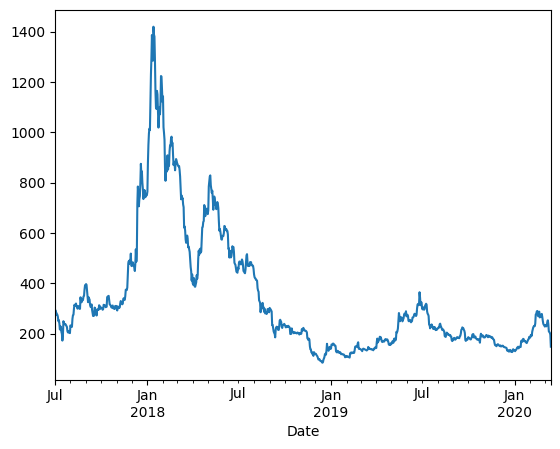

```python
highs.plot()
```

**Time: 29:15**

**Use resample on entire dataframe**  
Is it possible to resample multiple columns at once.  
Yes, if you run resample against the entire dataframe instead of on a single Series, as shown in the code below.

Use the same aggregation method on all of your columns.  
The code below resamples by each week.  
Use the same aggregation method on all columns.  
For the code below the mean aggregation method is being used on all df columns.  
The code below creates a DataFrame that contains the mean value for each column on a weekly basis.  
The index for the dataframe is Date.  
For this situation, it does not really make sense to get the average for all columns.  
For example, the point of a High and Low is to get the high and low values for that time period, i.e. the mean is not meaningful.

**Same aggregation method on all columns**  
The code below uses the same aggregation method on all columns.

**Video error**  
The video used the line of code below that is commented out, but it through an error.  
I changed the used the agg method as shown below and it worked.

```python
#df.resample('W').mean()
df.resample('W').agg({'Close': 'mean', 'High': 'mean', 'Low': 'mean', 'Volume': 'mean'})
```

| Date | Close | High | Low | Volume |
| --- | --- | --- | --- | --- |
| 2017-07-02 | 268.202162 | 271.124595 | 264.819730 | 2.185035e+06 |
| 2017-07-09 | 261.062083 | 262.872917 | 259.186190 | 1.337349e+06 |
| 2017-07-16 | 195.698393 | 199.204405 | 192.722321 | 2.986756e+06 |
| 2017-07-23 | 212.783750 | 215.779286 | 209.126310 | 4.298593e+06 |
| 2017-07-30 | 203.309524 | 205.110357 | 201.714048 | 1.581729e+06 |
| ... | ... | ... | ... | ... |
| 2020-02-16 | 255.198452 | 257.255238 | 252.679762 | 2.329087e+06 |
| 2020-02-23 | 265.321905 | 267.263690 | 262.948512 | 1.826094e+06 |
| 2020-03-01 | 236.373988 | 238.697500 | 234.208750 | 2.198762e+06 |
| 2020-03-08 | 229.817619 | 231.284583 | 228.373810 | 1.628910e+06 |
| 2020-03-15 | 176.332821 | 179.979487 | 172.936239 | 4.259828e+06 |

142 rows × 4 columns

Resample the entire df Dataframe, but use different aggregation methods that are appropriate for specific columns.  
Use the agg method. It accepts a map of columns and the aggregation method that we want to use on that column.  
The code below resamples df and the agg method receives a dictionary that specifies which aggregation method to use on each column.  
The keys for the dictionary are the column names.  
The Volume column is the volume of the trades for that week.

```python
df.resample('W').agg({'Close': 'mean', 'High': 'max', 'Low': 'min', 'Volume': 'sum'})
```

| Date | Close | High | Low | Volume |
| --- | --- | --- | --- | --- |
| 2017-07-02 | 268.202162 | 293.73 | 253.23 | 8.084631e+07 |
| 2017-07-09 | 261.062083 | 285.00 | 231.25 | 2.246746e+08 |
| 2017-07-16 | 195.698393 | 240.33 | 130.26 | 5.017750e+08 |
| 2017-07-23 | 212.783750 | 249.40 | 153.25 | 7.221637e+08 |
| 2017-07-30 | 203.309524 | 229.99 | 178.03 | 2.657305e+08 |
| ... | ... | ... | ... | ... |
| 2020-02-16 | 255.198452 | 290.00 | 216.31 | 3.912867e+08 |
| 2020-02-23 | 265.321905 | 287.13 | 242.36 | 3.067838e+08 |
| 2020-03-01 | 236.373988 | 278.13 | 209.26 | 3.693920e+08 |
| 2020-03-08 | 229.817619 | 253.01 | 196.00 | 2.736569e+08 |
| 2020-03-15 | 176.332821 | 208.65 | 90.00 | 4.983998e+08 |

142 rows × 4 columns